# Bumblebees

[NO_BUMB_001] (grasslands)  
[NO_BUMB_002] (forests)

Authors

Affiliation

Anders L. Kolstad

Norwegian Institute for Nature Research

Jens Åström

Norwegian Institute for Nature Research

Published

June 11, 2026

Reviewed by

Aud Halbritter

> **Recommended citation**: Kolstad, A., Åström, J., 2026. Bumblebees (ID(s): NO_BUMB_001_002) v. 1.0.0. ecRxiv: https://github.com/NINAnor/ecRxiv/tree/main/indicators/NO_BUMB_001_002

**Metadata**

Table 1: Indicator metadata

| Variable | Value |
| --- | --- |
| Indicator ID | NO_BUMB_001; NO_BUMB_002 |
| Indicator Name | Bumblebees |
| Country | Norway |
| Continent | Europe |
| Ecosystem Condition Typology Class | B1 - Compositional State Characteristics |
| Realm | Terrestrial |
| Biome | T4 Savannas and grasslands biome; T2 Temperate-boreal forests and woodlands biome |
| Ecosystem | T4.5 Temperate grasslands; T2.1 Boreal/montane forests |
| Year added | 2025 |
| Last update | 2026 |
| Version | 1.0.0 |
| Version comment | Similar as 000.003, but now it exports uncertainty distributions centered on the point estimates |
| Normalised | TRUE |
| Spatial aggregation pathway | Sp.agg. (regions to national) |

**Log**

- Aughust 21, 2025 - Started work
- September 2, 2025 - Added 3.6, 5.1 and 5.2
- November 24, 2025 - restructured metadata and added open science badges (ALK)
- June 10, 2026 - new version

**Session Info**

This workflow uses `renv`. Run `renv::restore()` to recreate the working environment in an R session.

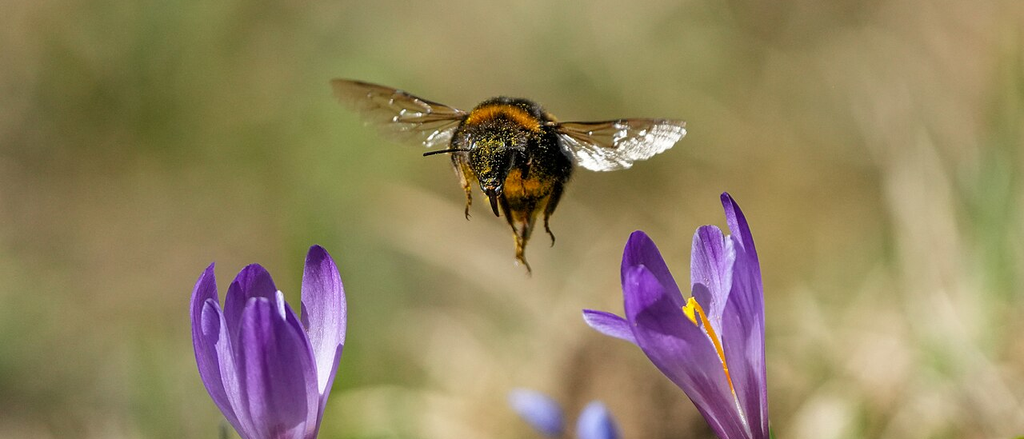

Figure 1: Bumblebee. Photo: Giles Laurent. CC-BY-SA 4.0.

```r
knitr::include_graphics(here::here("img/Humbe_Photo_Giles_Laurent_CCBYSA40.png"))
```

## 2. About the underlying data

The Norwegian monitoring of bumblebees and butterflies (NMBB) is initiated and financed by the Environmental agency, with the aim to produce continuous area representative time-series of insect community data. The NMBB program uses sweep netting along transect walks where the species are identified manually in the field.

NMBB is designed to be area representative, within the respective habitat types (forest and grasslands) and regions. It uses stratified randomized selection of localities. Localities are selected from a predefined continuous network of survey squares, within which individual transects are then manually placed. Some subjective decisions are made in the definition of habitat criteria and in discarding impractical survey locations.

### 2.1 Spatial and temporal resolution and extent

There are in total 71 sampling locations as of 2024, divided between the forests and the grassland ecosystem. The four regions have approx. the same sample size, yet they cover quite different extents (Figure 2). In this sense, the dataset is perhaps more suited, or at least better designed, to analysing regional difference, rather than to look at national means.

Since the same locations are visited each year, yearly estimates of the condition could be calculated, but should be interpreted with caution due to natural yearly variability.

### 2.2 Sampling design

A number of 50 m transects are selected from each sampling locality. All butterflies (and bumblebees) are identified along this transect, with 2,5 m buffer to each side. Field work was only done if it was either above 15 degree C, or less than 60% cloud cover (Öberg et al. 2011).

### 2.3 Original units

Original units are number of individuals of each species within a transect, although only presences in transects (as presence frequencies) are used for the indicator calculations.

#### 2.4 Instructions for citing, using and accessing data

We get the data from the GitHub repository for the R package (https://github.com/NINAnor/bombLepiSurv). Most of the data is also available on GBIF (Åström and Åström 2025) and in an internal server at NINA.

## 3. Indicator properties

### 3.1 Ecosystem Condition Typology Class (ECT)

B1 - Compositional state characteristics. This indicator fits here as it describes biotic communities.

### 3.2 Ecosystem condition characteristic

The indicator is designed to measure the degree to which ecosystems have intact biotic communities.

### 3.3 Collinearities with other indicators

Possibly co-varied with NO_BFLY (Kolstad and Åström 2026) as they both represent insect communities and rely on the same sampling locations and partly on the same sampling protocol.

### 3.4 Impact factors

Bumblebees in Norway are negatively affected by the loss and fragmentation of flower rich habitats in the agricultural landscape, including good nest sites (Ødegaard et al. 2021). The reduction in good habitat is attributed to both land abandonment and increased land use intensity (pesticides, fertilizer use with reduced flower diversity).

### 3.5 Spatial aggregation

The data comes into this workflow directly as an indicator, and there is no need to normalise them. The spatial resolution is that of geographical regions. The regions are used as is, and these regional uncertainty distributions are propagated, without weights, to a national estimate.

$$sp. agg. (regions\ to\ national)$$

## 4. Reference condition and levels

### 4.1 Reference condition

The reference condition for forests is one with minimal negative human impact (pre modern forestry and accelerated climate change for example), but there is a special interpretation for semi-natural land. These habitats are formed and maintained through human activities. Thus, “minimal negative human impact” is replaced by a state of “good maintenance”, here understood as resembling the traditional agricultural maintenance regime, existing for several hundred years up until the late 1800s. This is characterized by extensive grazing, meadows and lays, crop rotation with legumes to bind nitrogen in addition to fertilization from manure, relatively small field sizes and abundant field margins, and a lack of artificial fertilization and mechanized tilling.

### 4.2 Reference levels

Reference levels are calculated the same way as for Kolstad and Åström (2026), but repeated here for coherency.

Assessing the current state of insect communities is a complicated task, due to their taxonomic and functional breadth and high temporal and spatial variability. Still, even more challenging is establishing reference levels, when the reference states are extinct or prohibitively difficult to measure empirically.

For the bumblebee indicator, the communities are small enough and well-known enough to identify reference communities by expert opinion. These reference communities specify the expected rate of observing each species. The current rates of observation are then compared to the expected rates. The calculations are further explained below.

We have not specified a value for good ecological condition (X<sub>60</sub>) as of yet, since we lack a straightforward empirical basis to do so. By default then, the value is set to 0.6 , following the general framework.

The indicator summarizes the state of a bumblebee community by estimating the difference from a reference community. Formally, the community indicator (CI) is expressed as the relative change of the community from a state of reference (SR), where the change is calculated by a state of change (SC).

$$CI = \frac{SR-SC}{SR}$$

The state of reference (SR) represents a community of species which can be expected to be observed in a given habitat type and region. It is calculated by assigning each species to class of expected commonality: common (C), sporadic (S) and rare (R) species. This classification is done by expert opinion, informed by known present and past species distributions. Note that this state of reference only contains a subset of highlighted species, making up a historical reference community. Potential observations of “new” species therefore don’t inform the indicator value at all. Common species are expected to be observed in at least 5 % of the surveyed transects in a habitat type and region. Sporadic species similarly are defined as having a presence below 5 % but above 1 %. Rare species are seen in no more than 1 % of the transects, and lastly, species not seen in any transect are assumed as lost (L) for the purpose of this calculation.

Each commonality class gets its own weight, so that common species inform the reference state more than sporadic species, followed by rare species. The state of reference (SR) is thus a value where each species adds to the state according to its commonality. Formally, it is defined as:

$$SR = n_C * w_{C, SR} + n_S * w_{S, SR} + n_R * w_{R, SR} = \sum_{i = (C, S, R)} n_i * w_{i, SR},$$

where $n_i$ is the number of species in a commonality class (C, S, R), and the weights $[w_{C, SR}, w_{S, SR}, w_{R, SR}]$ specify their respective contribution to the reference state (SR). The weights used are $[w_{C, SR}, w_{S, SR}, w_{R, SR}] = [1.0, 0.75, 0.50]$, i.e. a sporadic species has 75 % the weight of a common species, and a rare species has 50 % the weight of a common species.

The state of change (SC) is calculated as

$$SC = n_{CS} * w_{CS} + n_{CR} * w_{CR} + n_{CL} * w_{CL} + n_{SR} * w_{SR} + n_{SL} * w_{SL} + n_{RL} * w_{RL}$$

where $n_{CS}$ is the number of expected common species (C) that is observed sporadically (S), and $w_{CS}$ is the weight of this change. Similarly, $n_{CR}$ is the number of expected common species that is observed rarely, $n_{RL}$ is the number of rare species that is lost, and so on. Potential increases in observation rates do not inform the indicator. Changes for common species are weighted more heavily than changes for less common species, and larger decreases are weighted more heavily than smaller decreases, such that $[w_{CS}, w_{CR}, w_{CL}, w_{SR}, w_{SL}, w_{RL}]= [0.50, 0.75, 1.00, 0.50, 0.75, 0.50]$.

#### 4.2.1 Spatial resolution and validity

Reference levels are unique to each region. They reflect the assumed *mean* community assemblage of bumblebees in that region, and therefore indicator values should not be presented at a spatial scale that is smaller than region. Note that there is no *variable* (in SEEA EA terms) associated with this indicator, and the indicator is normalised from the beginning, and before any spatial aggregation.

## 5. Uncertainties

### 5.1 General uncertainties

We think the main sources of uncertainty for this indicator has to do with (1) the representativity of the spatial sampling and how well it represents the ecosystem type in question, (2) and the precision of the reference community and the way the variable is normalised.

For the first point we note that bumblebees are flying insects that use resources in a range of habitats outside, or embedded within, what we use as the target ecosystem type. In addition, the spatial sampling is a stratified point sampling where some regions are intentionally left out. The national estimates therefore don’t include data from the entire country.

The second point refers to the reference communities, that are defined based on expert knowledge. These are not reproducible or based on strong empirical data.

### 5.2 Reported uncertainties

The indicator values are estimated with an inferential type of uncertainty for the true parameter value. The uncertainties for the regions is created using a randomization draw procedure, and it is a little unclear if this is truly an inferential type of uncertainty, but it is treated as such.

## 6. References

Åström, S., and J. Åström. 2025. “Bumblebees and Butterflies in Norway. Version 1.9.” Norwegian Institute for Nature Research. https://doi.org/10.15468/mpsa4g.

Åström, S., J. Åström, K. Bøhn, and S. Dahle. 2024. “Nasjonal overvåking av dagsommerfugler og humler i Norge. Oppsummering av aktiviteten i 2023.” *NINA Rapport 2388*. https://brage.nina.no/nina-xmlui/handle/11250/3116164.

Kolstad, Anders, and Jens Åström. 2026. “Butterflies (ID(s): NO_BFLY_001_002).” ecRxiv. https://github.com/NINAnor/ecRxiv/tree/main/indicators/NO_BFLY_001_002.

Öberg, S., J. O. Gjershaug, O. Diserud, and F. Ødegaard. 2011. “Videreutvikling av metodikk for arealrepresentativ overvåking av dagsommerfugler og humler. Naturindeks for Norge.” *NINA Rapport 663*. https://brage.nina.no/nina-xmlui/handle/11250/2500285.

Ødegaard, F., M. Sydenham, A. Staverløkk, and O. J. Lønnve. 2021. “Artsgruppeomtale Vepser (Hymenoptera). Norsk Rødliste for Arter 2021.” Artsdatabanken. https://www.artsdatabanken.no/rodlisteforarter2021/Artsgruppene/Vepser.

## 7. Datasets

### 7.1 Dataset A - NMBB

The `bombLepiSurv` package has convenience functions to fetch data from the internal NINA database. This database is currently not available outside NINA, so we will instead get the data from the GitHub repo. Indicator data is already processed and we can get them from the R package like this:

```r
# List datasets
dat <- CursoRopen::list_github_files(
  "bombLepiSurv",
  path = "data/",
  owner = "NINAnor",
  regexp = "hInd") # the 'h' is for humler/bumblebees. add regexp = "Gress" to filter for just grasslands

# remove the first part of the path
dat <- str_remove(dat, "data/")
# and the second part
dat <- str_remove(dat, ".rda")

# read in all the data (as promise)
data(package = "bombLepiSurv", list = dat)
```

The indicator data is stored in the environment as one dataframe per year/region/habitat.

### 7.2. Dataset B - Regions

We here import the delineations used in this monitoring program. Note that this delineation differs from the more standard definitions used in ecosystem accounting Norway. For details on how this regional delineations map is produced, please see Kolstad et al. (2026).

```r
readRDS(here::here("data/regions.rds")) -> counties
```

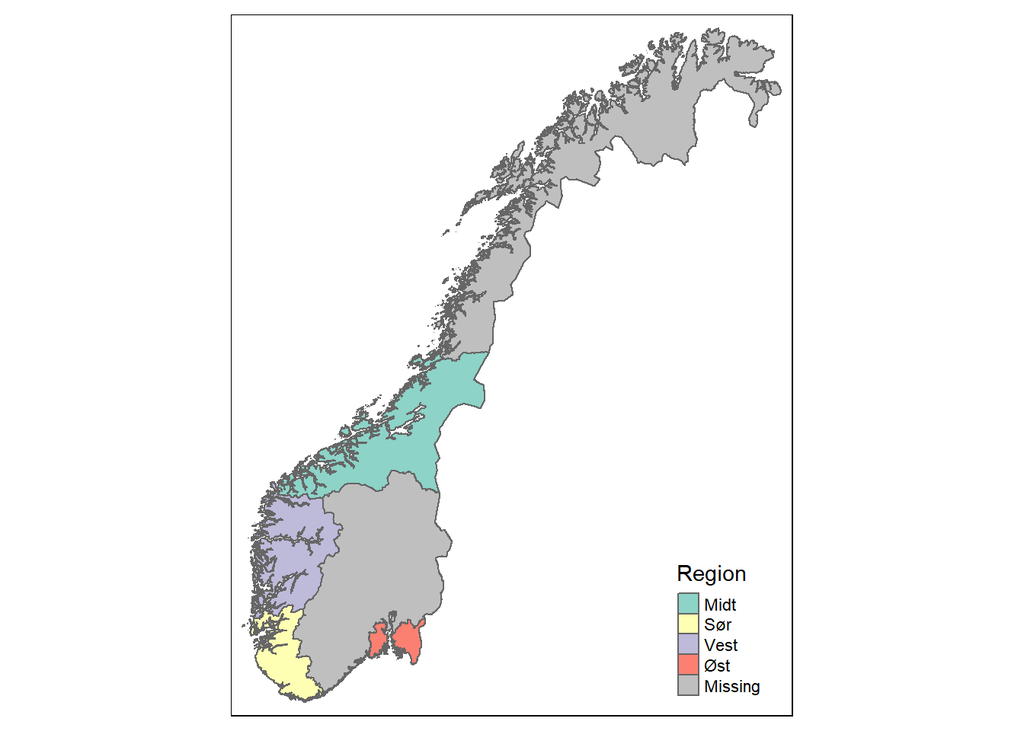

Figure 2: Regions in Norway

```r
tm_shape(counties) +
  tm_polygons(col = "Region") +
  tm_layout(legend.position = c("right", "bottom"))
```

## 8. Spatial units

The indicator values are calculated at the scale of geographic regions, which I refer to as basal units or BS units. These are not the same geographic regions that we are asked to calculate indicator values for in the ecosystem assessment project in 2026, where Rogaland belongs to the western region. In this indicator, Rogaland belongs to the southern region (Figure 2). It is not possible to split the data point between the regions, since the indicator is defined based on this *a priori* collation of localities. I therefore chose to simply use the regions as is.

Ecosystem assets (EA): Western-, central-, easters-, and southern Norway. Note that eastern Norway only includes the old counties of Vestfold and Østfold, and the south region contains Rogaland and Vest Agder, but not Øst Agder. The mid or central region includes Trøndelag and Møre og Romsdal. As noted above, we say that BSs equals EAs.

Ecosystem accounting area: Norway (although N-Norway and several sub-regions are missing).

## 9. Analyses

These calculations with bootstrap sampling are implemented in the R-package bombLepiSurv.

Indicator values are computed at the level of BSs directly from the field data. The uncertainties around the point estimates are from resampling localities with the EA, with replacement. This resampling procedure causes a downwards shift in the distribution of indicator values, at leastly partly because the species richness tends to decrease as some localities are selected more than once. In order to harmonise with other indicator workflows in Norway, our workflow here also needs to result in uncertainty distributions where the point estimate is defined as the median of this distribution. The uncertainty distribution, we believe, has a shape and spread which is representative of the true parameter uncertainty. Therefore we will shift this distribution to become centered on the point estimate, as it is from the original, non-resampled data.

Only locations with complete sampling (three replicated per season) should be included to avoid seasonal biases.

```r
draw_col <- "Randomization draws, community"
draw_col2 <- "Community indicator estimates, with percentiles"


meta <- tribble(
  ~year , ~region , ~obj               ,
   2020 , "E"     , hInd2020OstGress   ,
   2021 , "E"     , hInd2021OstGress   ,
   2022 , "E"     , hInd2022OstGress   ,
   2023 , "E"     , hInd2023OstGress   ,
   2024 , "E"     , hInd2024OstGress   ,

   2022 , "W"     , hInd2022VestGress  ,
   2023 , "W"     , hInd2023VestGress  ,
   2024 , "W"     , hInd2024VestGress  ,

   2020 , "S"     , hInd2020SorGress   ,
   2021 , "S"     , hInd2021SorGress   ,
   2022 , "S"     , hInd2022SorGress   ,
   2023 , "S"     , hInd2023SorGress   ,
   2024 , "S"     , hInd2024SorGress   ,

   2020 , "C"     , hInd2020TrondGress ,
   2021 , "C"     , hInd2021TrondGress ,
   2022 , "C"     , hInd2022TrondGress ,
   2023 , "C"     , hInd2023TrondGress ,
   2024 , "C"     , hInd2024TrondGress ,

   2015 , "E"     , hInd2015OstGress   ,
   2016 , "E"     , hInd2016OstGress   ,
   2017 , "E"     , hInd2017OstGress   ,
   2018 , "E"     , hInd2018OstGress   ,
   2019 , "E"     , hInd2019OstGress   ,

   2015 , "S"     , hInd2015SorGress   ,
   2016 , "S"     , hInd2016SorGress   ,
   2017 , "S"     , hInd2017SorGress   ,
   2018 , "S"     , hInd2018SorGress   ,
   2019 , "S"     , hInd2019SorGress   ,

   2015 , "C"     , hInd2015TrondGress ,
   2016 , "C"     , hInd2016TrondGress ,
   2017 , "C"     , hInd2017TrondGress ,
   2018 , "C"     , hInd2018TrondGress ,
   2019 , "C"     , hInd2019TrondGress
)

seminat <- meta %>%
  mutate(
    indicator = map(obj, ~ .x[[draw_col]][1:1000]),
    point_estimate = map_dbl(obj, ~ .x[[draw_col2]]["Point estimate"])
  ) |>
  select(year1 = year, region, indicator, point_estimate) |>
  mutate(
    year = case_when(
      year1 %in% c(2015:2019) ~ 2019,
      year1 %in% c(2020:2024) ~ 2024,
      TRUE ~ year1
    )
  )
```

```r
seminat %>%
  count(year, region, name = "# years") |>
  gt::gt()
```

Table 2: Number of years of data from each geographic region.

| year | region | # years |
| --- | --- | --- |
| 2019 | C | 5 |
| 2019 | E | 5 |
| 2019 | S | 5 |
| 2024 | C | 5 |
| 2024 | E | 5 |
| 2024 | S | 5 |
| 2024 | W | 3 |

```r
draw_col <- "Randomization draws, community"
draw_col2 <- "Community indicator estimates, with percentiles"


metaF <- tribble(
  ~year , ~region , ~obj               ,
   2020 , "E"     , hInd2020OstSkog   ,
   2021 , "E"     , hInd2021OstSkog   ,
   2022 , "E"     , hInd2022OstSkog   ,
   2023 , "E"     , hInd2023OstSkog   ,
   2024 , "E"     , hInd2024OstSkog   ,

   2022 , "W"     , hInd2022VestSkog  ,
   2023 , "W"     , hInd2023VestSkog  ,
   2024 , "W"     , hInd2024VestSkog  ,

   2020 , "S"     , hInd2020SorSkog   ,
   2021 , "S"     , hInd2021SorSkog   ,
   2022 , "S"     , hInd2022SorSkog   ,
   2023 , "S"     , hInd2023SorSkog   ,
   2024 , "S"     , hInd2024SorSkog   ,

   2020 , "C"     , hInd2020TrondSkog ,
   2021 , "C"     , hInd2021TrondSkog ,
   2022 , "C"     , hInd2022TrondSkog ,
   2023 , "C"     , hInd2023TrondSkog ,
   2024 , "C"     , hInd2024TrondSkog ,

   2015 , "E"     , hInd2015OstSkog   ,
   2016 , "E"     , hInd2016OstSkog   ,
   2017 , "E"     , hInd2017OstSkog   ,
   2018 , "E"     , hInd2018OstSkog   ,
   2019 , "E"     , hInd2019OstSkog   ,

   2015 , "S"     , hInd2015SorSkog   ,
   2016 , "S"     , hInd2016SorSkog   ,
   2017 , "S"     , hInd2017SorSkog   ,
   2018 , "S"     , hInd2018SorSkog   ,
   2019 , "S"     , hInd2019SorSkog   ,

   2015 , "C"     , hInd2015TrondSkog ,
   2016 , "C"     , hInd2016TrondSkog ,
   2017 , "C"     , hInd2017TrondSkog ,
   2018 , "C"     , hInd2018TrondSkog ,
   2019 , "C"     , hInd2019TrondSkog
)

skog <- metaF %>%
  mutate(
    indicator = map(obj, ~ .x[[draw_col]][1:1000]),
    point_estimate = map_dbl(obj, ~ .x[[draw_col2]]["Point estimate"])
  ) |>
  select(year1 = year, region, indicator, point_estimate) |>
  mutate(
    year = case_when(
      year1 %in% c(2015:2019) ~ 2019,
      year1 %in% c(2020:2024) ~ 2024,
      TRUE ~ year1
    )
  )
```

Then I shift the distributions so that their mean equals the point estimate.

```r
seminat <- seminat |>
  rowwise() |>
  mutate(
    dist_mean = mean(indicator),
    shift = point_estimate - dist_mean,
    indicator_shifted = list(indicator + shift),
    shifted_mean = mean(indicator_shifted)
  )
seminat |>
  select(region, year, point_estimate, dist_mean, shift, shifted_mean)
```

```
# A tibble: 33 × 6
# Rowwise:
   region  year point_estimate dist_mean   shift shifted_mean
   <chr>  <dbl>          <dbl>     <dbl>   <dbl>        <dbl>
 1 E       2024          0.552     0.483 0.0692         0.552
 2 E       2024          0.603     0.571 0.0329         0.603
 3 E       2024          0.638     0.579 0.0592         0.638
 4 E       2024          0.603     0.529 0.0748         0.603
 5 E       2024          0.621     0.599 0.0212         0.621
 6 W       2024          0.528     0.494 0.0344         0.528
 7 W       2024          0.566     0.536 0.0300         0.566
 8 W       2024          0.623     0.616 0.00632        0.623
 9 S       2024          0.593     0.535 0.0574         0.593
10 S       2024          0.519     0.498 0.0202         0.519
# ℹ 23 more rows
```

```r
skog <- skog |>
  rowwise() |>
  mutate(
    dist_mean = mean(indicator),
    shift = point_estimate - dist_mean,
    indicator_shifted = list(indicator + shift),
    shifted_mean = mean(indicator_shifted)
  )
```

Then we can use MC propagation of uncertainties to get an estimate and an uncertainty distribution for Norway as a whole. This raises a question about how to weigh the different regions. Figure 2 show how eastern Norway is only represented with data from a very small part. In the other regions, the sampling is more spread out. If we give the eastern region a low weight, matching the area that they cover in the map, the national estimate, which will be used to infer about all of Norway, including the unsampled areas, will be dictated by the other regions. Also within the Agder county, the sampling is not very spread out, so that giving this data a weight proportional to that county would not make more sense than giving the eastern localities a weight proportional to the eastern region. Because of this rather untidy delineation of regions and spreading of sampling localities, I will give each region an equal weight in the national estimate.

```r
out <- seminat |>
  select(year, part = region, indicator = indicator_shifted) |>
  add_column(end = "Norway", wgt = 1) |>
  unnest(indicator)

temp <- ecTools::ec_upscale(
  data = out,
  variable = indicator,
  weight = wgt,
  start_units = part,
  end_units = end,
  year = year,
  end_units_name = "part",
  n = 1000
)

out <- out |>
  select(year, part, indicator) |>
  bind_rows(temp |> rename(indicator = sampled_mean))

write.csv(out, file = here::here("data/results_NO_BUMB_001_v1.0.0.csv"), row.names = F)
```

```r
outF <- skog |>
  select(year, part = region, indicator = indicator_shifted) |>
  add_column(end = "Norway", wgt = 1) |>
  unnest(indicator)

temp <- ecTools::ec_upscale(
  data = outF,
  variable = indicator,
  weight = wgt,
  start_units = part,
  end_units = end,
  year = year,
  end_units_name = "part",
  n = 1000
)

outF <- outF |>
  select(year, part, indicator) |>
  bind_rows(temp |> rename(indicator = sampled_mean))

write.csv(outF, file = here::here("data/results_NO_BUMB_002_v1.0.0.csv"), row.names = F)
```

## 10. Results

The final indicator values for geographic regions, and Norway as a whole, are given in Table 3.

```r
summary_out <- out |>
  group_by(part, year) |>
  summarise(
    median = round(median(indicator), 2),
    p_025 = round(quantile(indicator, probs = 0.025), 2),
    p_25 = round(quantile(indicator, probs = 0.25), 2),
    p_75 = round(quantile(indicator, probs = 0.75), 2),
    p_975 = round(quantile(indicator, probs = 0.975), 2),
  ) |>
  add_column(
    ECT = "B1",
    Indicator = "Bumblebees",
    Ecosystem = "Semi-natural",
    ID = "NO_BUMB_001"
  )

summary_outF <- outF |>
  group_by(part, year) |>
  summarise(
    median = round(median(indicator), 2),
    p_025 = round(quantile(indicator, probs = 0.025), 2),
    p_25 = round(quantile(indicator, probs = 0.25), 2),
    p_75 = round(quantile(indicator, probs = 0.75), 2),
    p_975 = round(quantile(indicator, probs = 0.975), 2),
  ) |>
  add_column(
    ECT = "B1",
    Indicator = "Bumblebees",
    Ecosystem = "Forest",
    ID = "NO_BUMB_002"
  )
```

```r
summary_out |>
  unite(col = "CI_95", c(p_025, p_975), sep = " - ") |>
  unite(col = "IQR", c(p_25, p_75), sep = " - ") |>
  arrange(year, part) |>
  select(
    ECT,
    Indicator,
    ID,
    "Accounting area" = part,
    Ecosystem,
    "Closing year" = year,
    "Indicator value" = median,
    "95% CI" = CI_95,
    "50% CI" = IQR
  ) |>
  knitr::kable()
```

Table 3: Indicator values (median values) and uncertainty estimates for NO_BUMB_001. Semi-natural ecosystems are part of the main ecosystem type “Open lowlands”.

| ECT | Indicator | ID | Accounting area | Ecosystem | Closing year | Indicator value | 95% CI | 50% CI |
| --- | --- | --- | --- | --- | --- | --- | --- | --- |
| B1 | Bumblebees | NO_BUMB_001 | C | Semi-natural | 2019 | 0.67 | 0.55 - 0.78 | 0.59 - 0.72 |
| B1 | Bumblebees | NO_BUMB_001 | E | Semi-natural | 2019 | 0.57 | 0.35 - 0.71 | 0.47 - 0.64 |
| B1 | Bumblebees | NO_BUMB_001 | Norway | Semi-natural | 2019 | 0.60 | 0.5 - 0.69 | 0.56 - 0.63 |
| B1 | Bumblebees | NO_BUMB_001 | S | Semi-natural | 2019 | 0.56 | 0.47 - 0.71 | 0.53 - 0.62 |
| B1 | Bumblebees | NO_BUMB_001 | C | Semi-natural | 2024 | 0.73 | 0.57 - 0.83 | 0.68 - 0.78 |
| B1 | Bumblebees | NO_BUMB_001 | E | Semi-natural | 2024 | 0.61 | 0.45 - 0.71 | 0.56 - 0.66 |
| B1 | Bumblebees | NO_BUMB_001 | Norway | Semi-natural | 2024 | 0.63 | 0.56 - 0.69 | 0.6 - 0.65 |
| B1 | Bumblebees | NO_BUMB_001 | S | Semi-natural | 2024 | 0.61 | 0.45 - 0.71 | 0.55 - 0.66 |
| B1 | Bumblebees | NO_BUMB_001 | W | Semi-natural | 2024 | 0.58 | 0.45 - 0.67 | 0.52 - 0.61 |

```r
summary_outF |>
  unite(col = "CI_95", c(p_025, p_975), sep = " - ") |>
  unite(col = "IQR", c(p_25, p_75), sep = " - ") |>
  arrange(year, part) |>
  select(
    ECT,
    Indicator,
    ID,
    "Accounting area" = part,
    Ecosystem,
    "Closing year" = year,
    "Indicator value" = median,
    "95% CI" = CI_95,
    "50% CI" = IQR
  ) |>
  knitr::kable()
```

Table 4: Indicator values (median) and uncertainty estimates for NO_BUMB_002.

| ECT | Indicator | ID | Accounting area | Ecosystem | Closing year | Indicator value | 95% CI | 50% CI |
| --- | --- | --- | --- | --- | --- | --- | --- | --- |
| B1 | Bumblebees | NO_BUMB_002 | C | Forest | 2019 | 0.74 | 0.57 - 0.93 | 0.68 - 0.77 |
| B1 | Bumblebees | NO_BUMB_002 | E | Forest | 2019 | 0.46 | 0.34 - 0.68 | 0.42 - 0.52 |
| B1 | Bumblebees | NO_BUMB_002 | Norway | Forest | 2019 | 0.59 | 0.5 - 0.7 | 0.55 - 0.62 |
| B1 | Bumblebees | NO_BUMB_002 | S | Forest | 2019 | 0.55 | 0.39 - 0.77 | 0.49 - 0.6 |
| B1 | Bumblebees | NO_BUMB_002 | C | Forest | 2024 | 0.65 | 0.41 - 0.79 | 0.57 - 0.7 |
| B1 | Bumblebees | NO_BUMB_002 | E | Forest | 2024 | 0.54 | 0.35 - 0.7 | 0.48 - 0.61 |
| B1 | Bumblebees | NO_BUMB_002 | Norway | Forest | 2024 | 0.61 | 0.52 - 0.68 | 0.58 - 0.63 |
| B1 | Bumblebees | NO_BUMB_002 | S | Forest | 2024 | 0.54 | 0.44 - 0.79 | 0.52 - 0.62 |
| B1 | Bumblebees | NO_BUMB_002 | W | Forest | 2024 | 0.69 | 0.57 - 0.79 | 0.63 - 0.71 |

```r
part_labels <- c(
  N = "North",
  C = "Central",
  W = "West",
  S = "South",
  E = "East",
  Norway = "Norway",
  All = "Norway"
)

region_levels <- c("Norway", "Central", "East", "North", "South", "West")

region_cols <- setNames(
  MetBrewer::met.brewer("Archambault", n = length(region_levels)),
  region_levels
)
myYears <- c(2019, 2024)
plot_data <- summary_out |>
  mutate(
    year = factor(year, levels = myYears),
    series_type = if_else(part == "Norway", "National", "Region"),
    part2 = recode(part, !!!part_labels)
  )

plot_dataF <- summary_outF |>
  mutate(
    year = factor(year, levels = myYears),
    series_type = if_else(part == "Norway", "National", "Region"),
    part2 = recode(part, !!!part_labels)
  )
```

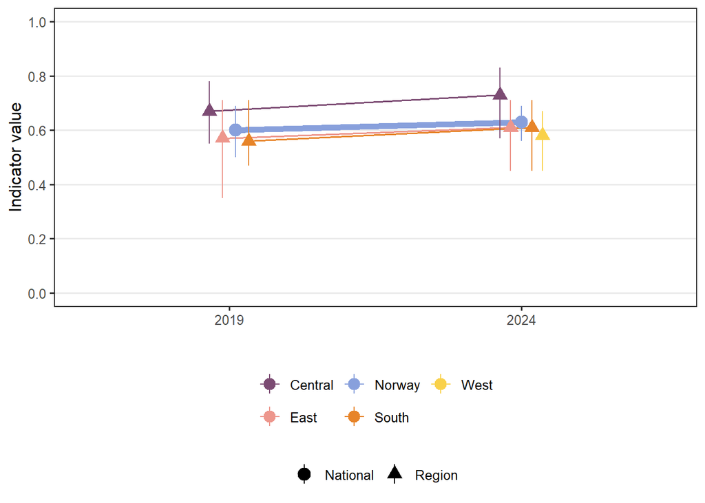

Figure 3: Indicator values for NO_BUMB_001 (Bumblebees in semi-natural or agricultural ecosystems) plotted over time and for four different regions (there is no data from Northern Norway), as well as the combined national estimate. The error bars are 95% confidence intervals.

```r
ggplot(plot_data, aes(x = year, y = median, colour = part2, group = part2)) +
  geom_line(
    aes(linewidth = series_type),
    position = position_dodge(width = 0.18)
  ) +
  scale_linewidth_manual(
    values = c(National = 2, Region = 0.55),
    guide = "none"
  ) +
  geom_pointrange(
    aes(ymin = p_025, ymax = p_975, shape = series_type),
    size = 0.8,
    linewidth = 0.45,
    position = position_dodge(width = 0.18)
  ) +
  scale_colour_manual(values = region_cols, name = NULL) +
  scale_shape_manual(
    values = c(National = 19, Region = 17),
    name = NULL
  ) +
  scale_y_continuous(limits = c(0, 1), breaks = seq(0, 1, 0.2)) +
  theme_bw(base_size = 12) +
  theme(
    legend.position = "bottom",
    legend.box = "vertical",
    panel.grid.minor = element_blank(),
    panel.grid.major.x = element_blank()
  ) +
  guides(
    colour = guide_legend(
      nrow = 2,
      override.aes = list(size = 0.7, linewidth = 0.45)
    ),
    shape = guide_legend(override.aes = list(size = 0.8, linewidth = 0.45))
  ) +
  labs(y = "Indicator value", x = "")
```

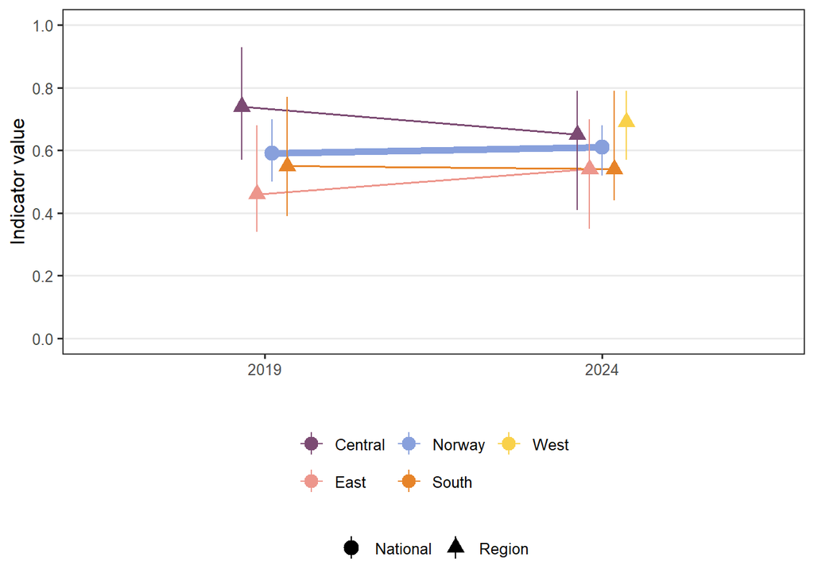

Figure 4: Indicator values for NO_BUMB_002 (Bumblebees in forest ecosystems) plotted over time and for four different regions (there is no data from Northern Norway), as well as the combined national estimate. The error bars are 95% confidence intervals.

```r
ggplot(plot_dataF, aes(x = year, y = median, colour = part2, group = part2)) +
  geom_line(
    aes(linewidth = series_type),
    position = position_dodge(width = 0.18)
  ) +
  scale_linewidth_manual(
    values = c(National = 2, Region = 0.55),
    guide = "none"
  ) +
  geom_pointrange(
    aes(ymin = p_025, ymax = p_975, shape = series_type),
    size = 0.8,
    linewidth = 0.45,
    position = position_dodge(width = 0.18)
  ) +
  scale_colour_manual(values = region_cols, name = NULL) +
  scale_shape_manual(
    values = c(National = 19, Region = 17),
    name = NULL
  ) +
  scale_y_continuous(limits = c(0, 1), breaks = seq(0, 1, 0.2)) +
  theme_bw(base_size = 12) +
  theme(
    legend.position = "bottom",
    legend.box = "vertical",
    panel.grid.minor = element_blank(),
    panel.grid.major.x = element_blank()
  ) +
  guides(
    colour = guide_legend(
      nrow = 2,
      override.aes = list(size = 0.7, linewidth = 0.45)
    ),
    shape = guide_legend(override.aes = list(size = 0.8, linewidth = 0.45))
  ) +
  labs(y = "Indicator value", x = "")
```

## 11. Export file

The results are exported to `data/results_NO_BUMB_001_v.1.0.0.csv` and `*_002v.1.0.0.csv`.

## 12. Author contributions

**CRediT statement**

- Conceptualization: ALK, JÅ
- Methodology: ALK, JÅ
- Data curation: JÅ
- Formal analysis: ALK, JÅ
- Software: ALK, JÅ
- Visualization: ALK
- Writing – original draft: ALK
- Writing – review & editing: JÅ
- Funding acquisition: ALK